# Prediction and insight from blackbox machine leanrning techiniques

## Introduction

In this project, I delved into the application of advanced machine learning techniques to train prediction models using the popular Kaggle dataset known as the Stroke Prediction Dataset. The dataset comprises 5110 observations (rows) indicating whether a specific patient experienced a stroke or not, along with 10 additional metrics (columns). These metrics encompass both personal and health-related features. The primary goal of working with this dataset was to develop a classification model that could accurately predict whether a patient had a stroke based on healthcare metrics. To achieve this, I employed two machine learning algorithms, namely Random Forest and Neural Net, and conducted a comparative analysis of their prediction accuracies. Furthermore, I conducted a thorough exploration of both machine learning techniques to uncover insights from these seemingly complex black-box models.

This notebook is outlined as follows:

1. Data Cleaning and Exploritory Data Analysis
2. Neural Network
3. Random Forest
4. Feature Importance
5. Conclusion

## 1.Data cleaning and Exploratory Data Analysis (EDA)

First, I loaded the necessary Python modules and read in the data for this analysis.

```python
from sklearn.model_selection import train_test_split
import pandas as pd
from sklearn.preprocessing import OneHotEncoder
from sklearn.preprocessing import StandardScaler
import tensorflow as tf
from sklearn.ensemble import RandomForestClassifier
from sklearn.metrics import accuracy_score, confusion_matrix, classification_report
from sklearn import tree
import shap
import numpy as np
import matplotlib.pyplot as plt
import seaborn as sns

df = pd.read_csv("/Users/tim/Desktop/Current/Prediction/Data/healthcare-dataset-stroke-data.csv")
```

Then, I looked at some basic summary statistics for each feature.

```python
summary_stats_continous = df.describe()
summary_stats_categorical = df.describe(include = 'object')

print(summary_stats_continous)
print(summary_stats_categorical)
```

```
                 id          age  hypertension  heart_disease  \
count   5110.000000  5110.000000   5110.000000    5110.000000
mean   36517.829354    43.226614      0.097456       0.054012
std    21161.721625    22.612647      0.296607       0.226063
min       67.000000     0.080000      0.000000       0.000000
25%    17741.250000    25.000000      0.000000       0.000000
50%    36932.000000    45.000000      0.000000       0.000000
75%    54682.000000    61.000000      0.000000       0.000000
max    72940.000000    82.000000      1.000000       1.000000

       avg_glucose_level          bmi       stroke
count        5110.000000  4909.000000  5110.000000
mean          106.147677    28.893237     0.048728
std            45.283560     7.854067     0.215320
min            55.120000    10.300000     0.000000
25%            77.245000    23.500000     0.000000
50%            91.885000    28.100000     0.000000
75%           114.090000    33.100000     0.000000
max           271.740000    97.600000     1.000000
        gender ever_married work_type Residence_type smoking_status
count     5110         5110      5110           5110           5110
unique       3            2         5              2              4
top     Female          Yes   Private          Urban   never smoked
freq      2994         3353      2925           2596           1892
```

The feature *BMI* had some NA's, and there were a few ways to handle them. Because it was only a few observations and was still plenty of data I removed the relevant rows.

```python
df = df.dropna()
df= df.reset_index(drop=True)
```

Next, I wanted to get an idea of what kinds of relationships there are between the features of this dataset. I categorized the features into 3 classes, numeric, binary and categorical.

```python
X_numeric = ["age", "bmi", "avg_glucose_level"]
X_binary = ["hypertension", "heart_disease"]
X_cat = ["gender", "ever_married", "work_type", "Residence_type", "smoking_status"]
```

First, I explored the numeric features.

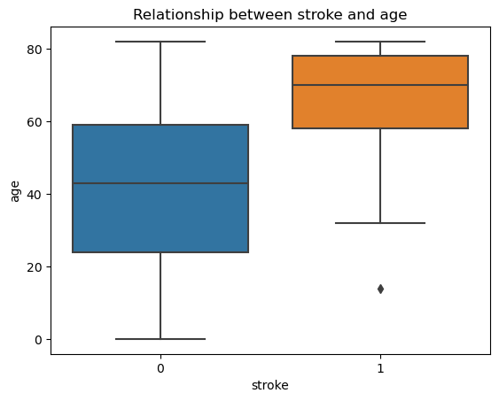

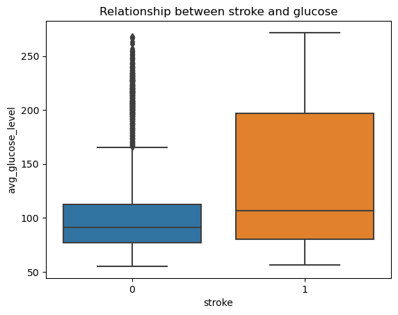

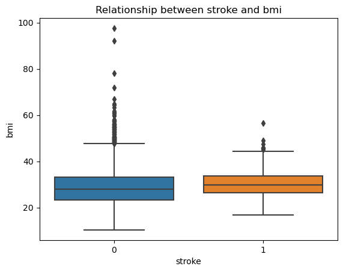

```python
# Stroke and age
sns.boxplot(x='stroke', y= "age", data = df)
plt.title(f"Relationship between stroke and age")
plt.show()

# stroke and glucose
sns.boxplot(x='stroke', y= "avg_glucose_level", data = df)
plt.title(f"Relationship between stroke and glucose")
plt.show()

# stoke and bmi
sns.boxplot(x='stroke', y= "bmi", data = df)
plt.title(f"Relationship between stroke and bmi")
plt.show()
```

Older patients seem to be the majority of stoke victims. Additionally, stoke patients tend to have higher bmi's and higher average glucose levels.

Next, I wanted to see the relationships between these numeric features.

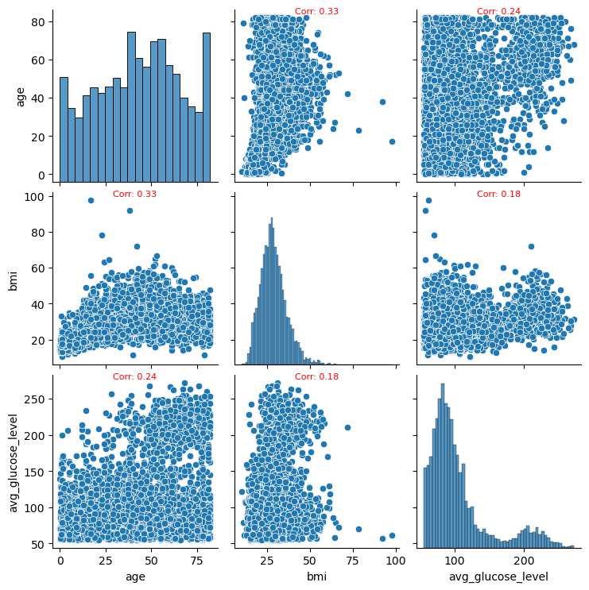

```python
scatter_matrix = sns.pairplot(df[X_numeric])

for i, (ax_row, feature_row) in enumerate(zip(scatter_matrix.axes, X_numeric)):
    for j, ax in enumerate(ax_row):
        if i != j:
            correlation_coefficient = df[[feature_row, X_numeric[j]]].corr().iloc[0, 1]
            ax.annotate(f'Corr: {correlation_coefficient:.2f}', xy=(0.5, 0.99), xycoords='axes fraction', ha='center', va='center', fontsize=8, color='red')

plt.show()
```

There were no obvious relationships between the features. I didn’t think there would be any issue of multicollinearity in future models.

Next, the binary features.

```python
pd.crosstab(df["stroke"], df["hypertension"], margins=True, margins_name='Total')
```

| hypertension stroke | 0 | 1 | Total |
| --- | --- | --- | --- |
| 0 | 4309 | 391 | 4700 |
| 1 | 149 | 60 | 209 |
| Total | 4458 | 451 | 4909 |

```python
pd.crosstab(df["stroke"], df["heart_disease"], margins=True, margins_name='Total')
```

| heart_disease stroke | 0 | 1 | Total |
| --- | --- | --- | --- |
| 0 | 4497 | 203 | 4700 |
| 1 | 169 | 40 | 209 |
| Total | 4666 | 243 | 4909 |

```python
pd.crosstab(df["hypertension"], df["heart_disease"], margins=True, margins_name='Total')
```

| heart_disease hypertension | 0 | 1 | Total |
| --- | --- | --- | --- |
| 0 | 4273 | 185 | 4458 |
| 1 | 393 | 58 | 451 |
| Total | 4666 | 243 | 4909 |

Interestingly, of the patients that had stokes most of them did not have prior heart disease. Also, the majority of patients that had stokes did not have hypertension.

Finally, I checked out the categorical features.

```python
pd.crosstab(df["stroke"], df["gender"], margins=True, margins_name='Total')
```

| gender stroke | Female | Male | Other | Total |
| --- | --- | --- | --- | --- |
| 0 | 2777 | 1922 | 1 | 4700 |
| 1 | 120 | 89 | 0 | 209 |
| Total | 2897 | 2011 | 1 | 4909 |

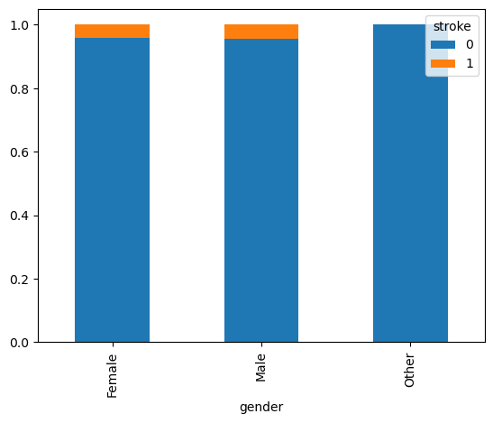

```python
pd.crosstab(df['gender'], df['stroke'], normalize='index').plot(kind='bar', stacked=True)
plt.show()
```

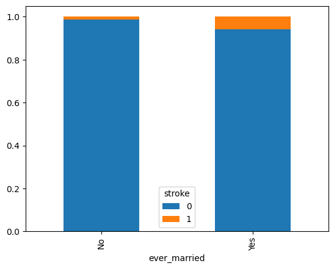

```python
pd.crosstab(df['ever_married'], df['stroke'], normalize='index').plot(kind='bar', stacked=True)
plt.show()
```

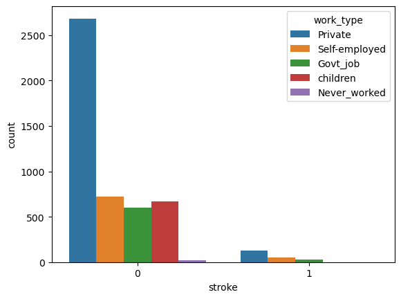

```python
sns.countplot(x='stroke', hue='work_type', data=df)
plt.show()
```

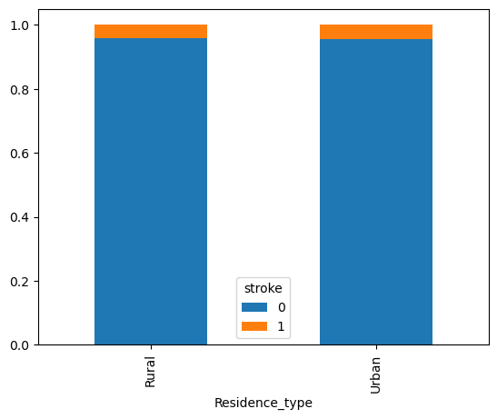

```python
pd.crosstab(df['Residence_type'], df['stroke'], normalize='index').plot(kind='bar', stacked=True)
plt.show()
```

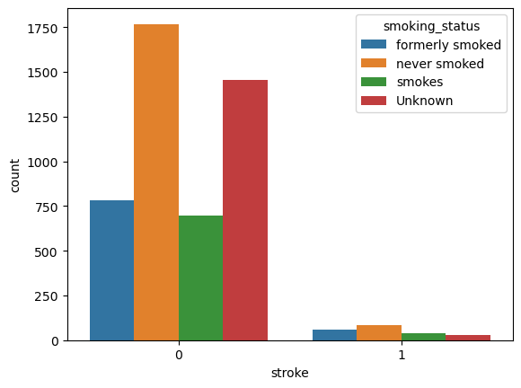

```python
sns.countplot(x='stroke', hue='smoking_status', data=df)
plt.show()
```

Upon reviewing the categorical features, it was observed that the sex distribution in the subsample of the population aligns with that among stroke victims. Consequently, gender does not appear to have been a determinable factor. Notably, a majority of stroke patients were married, and individuals who never worked also never experienced a stroke. Similarly, the proportions of rural and urban patients indicated no significant relationship. Concerning smoking status, no clear pattern emerged, but the high number of unknown smoking statuses for patients likely contributed to the lack of clarity.

After completing the Exploratory Data Analysis (EDA), a better understanding was gained regarding the available features for predicting stroke occurrences. The decision was made to incorporate all these features into the machine learning algorithms since there didn't seem to be any downside to including them, even if their relationships with strokes were weak.

### Model prep

Before training the algorithms, I did some data manipulation to aid in the process.

For the numeric features I centered and standardized.

```python
scaler = StandardScaler()
X_scaled = scaler.fit_transform(df[X_numeric])
X_scaled = pd.DataFrame(X_scaled, columns = X_numeric)
```

For the categorical variables I hot encoded them. This processed widened the tabular data and made each treatment within a category into a binary option.

```python
enc = OneHotEncoder(sparse_output=False, drop='first')
encoded_columns = enc.fit_transform(df[X_cat])
X_encoded = pd.DataFrame(encoded_columns, columns = enc.get_feature_names_out(X_cat))
X_format = pd.concat([X_scaled, X_encoded, df[X_binary]], axis=1)
```

I kept the originally binary features as was. Then I split the data into training and testing sets.

```python
y = df["stroke"]

X_train, X_test, y_train, y_test = train_test_split(X_format, y, test_size=0.2, random_state=10)
```

## 2. Nerural Network

I first fit the neural network within the module tensorflow.

```python
nn = tf.keras.models.Sequential()
nn.add(tf.keras.layers.Dense(32, activation='relu', input_dim=X_train.shape[1]))
nn.add(tf.keras.layers.Dense(16, activation='relu'))
nn.add(tf.keras.layers.Dense(1, activation='sigmoid'))
```

The neural network included two hidden layers with 32 and 16 neurons in each respectively. For each of the hidden layers the activation function used was relu and the final classification layers used a sigmoid function.

```python
nn.compile(optimizer='adam', loss='binary_crossentropy', metrics=['accuracy'])
```

For the training process an Adam optimizer was used, and the loss criteria was binary cross entropy (common for binary classification). Finally, the metric of importance is accuracy.

```python
nn.fit(X_train, y_train, epochs=10, batch_size=32, validation_data=(X_test, y_test))
```

```
<keras.callbacks.History at 0x14fbc2f10>
```

We can use a confusion matrix to have a better look at the predictions made on the testing data.

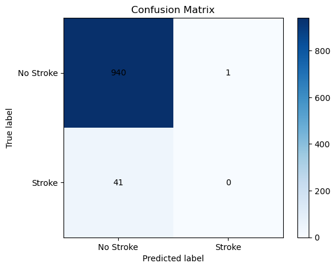

```python
predictions = nn.predict(X_test)
predicted_labels = np.round(predictions).flatten()
true_labels = y_test
conf_matrix = confusion_matrix(true_labels, predicted_labels)

plt.imshow(conf_matrix, interpolation='nearest', cmap=plt.cm.Blues)
plt.title('Confusion Matrix')
plt.colorbar()

classes = ['No Stroke', 'Stroke']  # Replace with your actual class labels
tick_marks = np.arange(len(classes))
plt.xticks(tick_marks, classes)
plt.yticks(tick_marks, classes)

# Adding annotations
for i in range(len(classes)):
    for j in range(len(classes)):
        plt.text(j, i, str(conf_matrix[i, j]), ha='center', va='center')

plt.ylabel('True label')
plt.xlabel('Predicted label')
plt.show()
```

The majority of predictions indicated no stroke, and the majority of actual values also turned out to be no stroke. However, it is noteworthy that most of the incorrect predictions were for patients who ultimately experienced a stroke. Despite the overall accuracy being satisfactory, caution should be exercised when considering its use in a production setting, given that the consequences of predicting no stroke and encountering one are considerably more severe than the alternative.

## 3. Random Forest

As stated, the other machine learning algorithm I used was Random Forest. Random Forest is an ensemble flavor of decision tree which has proven to be a very powerful machine learning technique for predictive purposes.

For fitting the Random Forest model, I used the features as were prepared for the neural net.

```python
rf = RandomForestClassifier(random_state = 10)
rf.fit(X_train, y_train)
```

```
RandomForestClassifier(random_state=10)
```

```python
y_pred_test = rf.predict(X_test)
y_pred_train = rf.predict(X_train)
print("in sample accuracy:", round(accuracy_score(y_train, y_pred_train), 2))
print("out of sample accuracy:", round(accuracy_score(y_test, y_pred_test), 2))
```

```
in sample accuracy: 1.0
out of sample accuracy: 0.96
```

Rather than immediately delving into the confusion matrix, as was done for the neural network, I opted to visualize the tree first to provide context for the model. Without delving too deeply into the intricacies of the Random Forest algorithm, it aggregates the consensus of many unpruned decision trees to establish a final model. This implies that visualizations may not offer substantial insights into the data. Nevertheless, I present them to illustrate the complexity of the decision tree after fitting.

[output not shown]

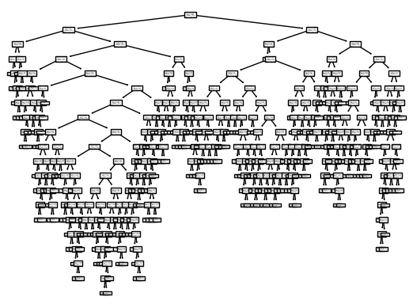

```python
tree.plot_tree(rf.estimators_[0])
```

Now, let's move into the confusion matrix and see the specifics of the predictions.

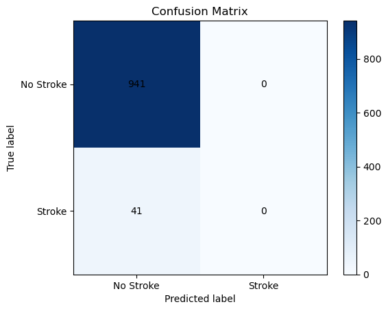

```python
y_pred = rf.predict(X_test)

conf_matrix = confusion_matrix(y_test, y_pred)

plt.imshow(conf_matrix, interpolation='nearest', cmap=plt.cm.Blues)
plt.title('Confusion Matrix')
plt.colorbar()

classes = ['No Stroke', 'Stroke']
tick_marks = np.arange(len(classes))
plt.xticks(tick_marks, classes)
plt.yticks(tick_marks, classes)

for i in range(len(classes)):
    for j in range(len(classes)):
        plt.text(j, i, str(conf_matrix[i, j]), ha='center', va='center')

plt.ylabel('True label')
plt.xlabel('Predicted label')
plt.show()
```

Addressing the challenge of false negatives, one could consider optimizing the algorithms to enhance the models. During the training of both models, I adhered to generic preset parameters for simplicity. However, I chose not to delve into optimization for the sake of simplicity in this analysis.

## 4. Feature importance

What insight can we get fom the trained machine leanring algorithims?

While both neural networks and random forests are essentially Blackbox techniques, implying limited understanding of the underlying processes, there have been advancements that allow us to gain insights into how machine learning algorithms are influenced by the features provided. Notably, feature importance comes to the forefront in this context. The specific approach I employed for the trained algorithms involved SHAP (SHapley Additive exPlanations) values. SHAP values, rooted in game theory, assign an importance value to each feature in a model. Furthermore, these values can be visualized to illustrate the relative importance of features compared to others in achieving prediction accuracy.

### Nerual Net Shap values

[output not shown]

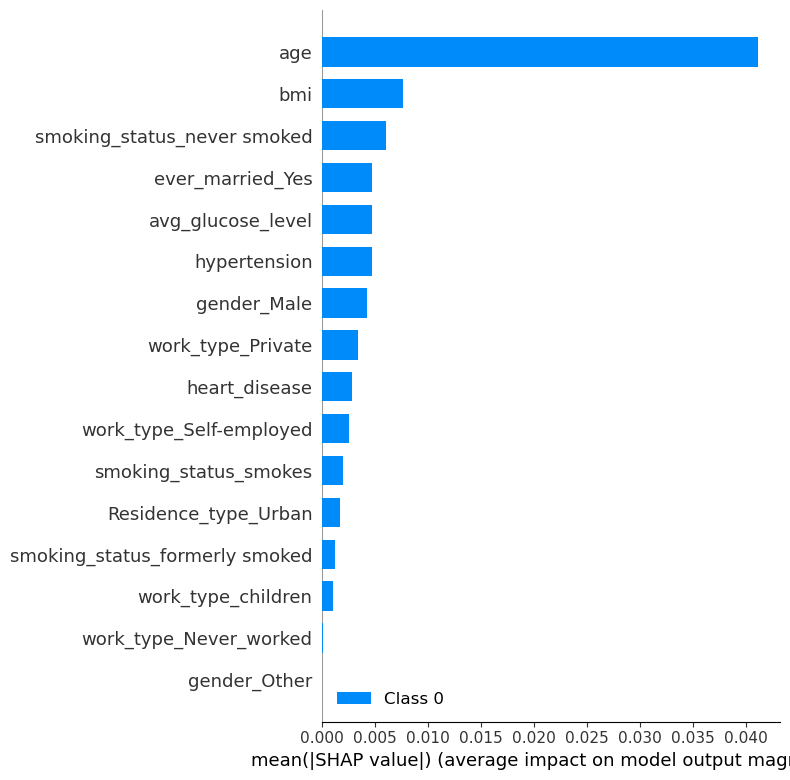

```python
explainer = shap.DeepExplainer(nn, np.array(X_train))
shap_values = explainer.shap_values(np.array(X_test))
shap.summary_plot(shap_values, np.array(X_test), feature_names=X_test.columns)
```

The generated bar plot above illustrates the mean SHAP values for features calculated from the testing dataset and the neural net. These values, on their own, do not provide a direct explanation of how well the trained algorithm predicts stroke patients. However, considering the tested accuracy exceeded 95%, the SHAP values serve as a reliable indication of which features contribute significantly to the high prediction accuracy. Analyzing the SHAP values, it was revealed that age, BMI, and the patient's smoking history were the three features with the most substantial impact on predictions for the testing dataset. Notably, age emerged as the most influential among these features.

### Random Forest Shap values

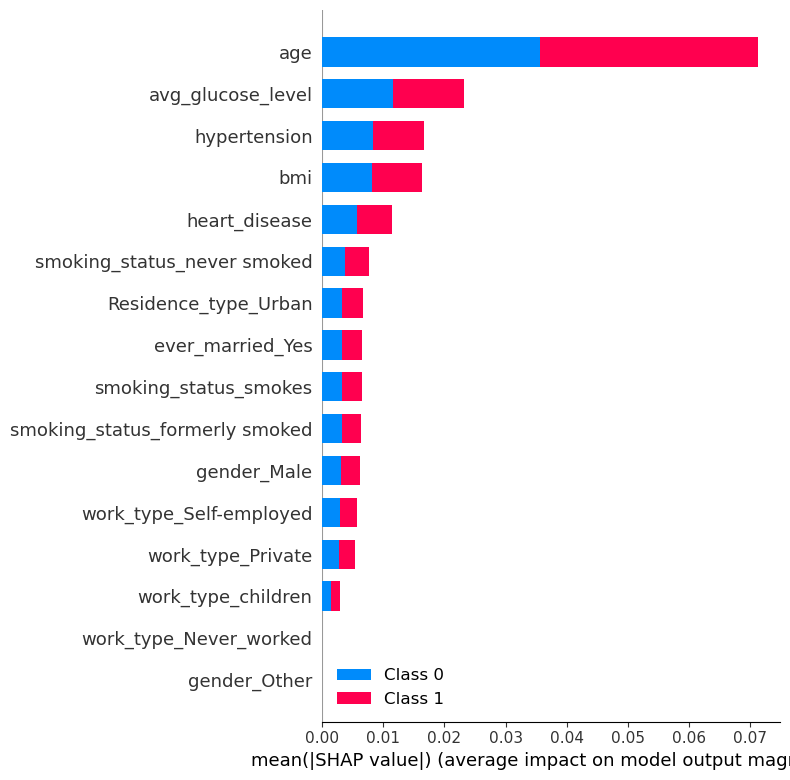

```python
explainer = shap.Explainer(rf)

shap_values = explainer.shap_values(X_test)

shap.summary_plot(shap_values, X_test, feature_names=X_test.columns)
```

The generated bar plot above illustrates the mean SHAP values for features calculated from the testing dataset and the random forest. Like the neural net age was the most impactful feature but I found a few other features that weighed more heavily for the random forest than it did for the neural net. For instance, average glucose level and hypertension were the second and third most important feature in obtaining the high prediction accuracy.

## 5. Conclusion

In the process of training and testing the two selected machine learning algorithms on the stroke patient dataset, I obtained prediction models with accuracies exceeding 95%. Furthermore, I identified key features contributing to this high accuracy, including age, BMI, average glucose level, and the presence of hypertension. Notably, a common trend in both trained algorithms was the occurrence of predominantly false negatives when errors arose. This finding raises concerns about deploying either of these algorithms into production within the healthcare field, as false negatives can have severe consequences. Careful consideration and potential improvements are necessary before implementing these models in a real-world healthcare setting.

Given the significant impact of features such as age, BMI, average glucose level, and the presence of hypertension on the accuracy of the prediction models, an avenue for improvement lies in expanding data collection for these critical features. Increasing the volume and diversity of data related to these key variables could provide the algorithms with a more comprehensive understanding of their relationships with stroke occurrences. This expanded dataset could help capture nuanced patterns and variations, leading to more robust and generalizable models. Additionally, incorporating additional relevant features or exploring interactions among existing features might further enhance the algorithms' predictive capabilities. The emphasis should be on obtaining a richer and more representative dataset that aligns closely with the critical factors influencing stroke prediction. Regular updates and refinements based on continuously growing datasets could contribute to the algorithms' adaptability and improved performance over time.